# Developmental curve comparison

Page and Mike

2016-02-24

```
## [1] "../data/infant_directed_speech_preference.csv"
## [1] "../data/label_advantage.csv"
## [1] "../data/mutual_exclusivity.csv"
## [1] "../data/phonemic_discrimination_native.csv"
## [1] "../data/phonemic_discrimination_nonnative.csv"
## [1] "../data/transitive_alternation.csv"
## [1] "../data/word_segmentation.csv"
```

```r
xtabs(~dataset, all_data)
```

```
## dataset
##    Infant directed speech preference  Label advantage in concept learning
##                                   50                                  100
##                   Mutual exclusivity     Phonemic discrimination (native)
##                                   60                                  136
## Phonemic discrimination (non-native)                    Word segmentation
##                                   46                                  260
```

# 1 Introduction

The goal for this analysis was to better understand the shape of the developmental curve. To do this we examined both general curves across all data sets and curves taking into account data set specific variance.

Summary of investigations:

- Running regressions over the entire data set is not appropriate.
- Looked at meta-analytic mixed effects - this approach is promising, but…
- The random effects structure (specifically if we nest paper effects within dataset effects) makes a big difference to the implied curve shape.

# 2 Plots

First look at the whole data set with various model types: 1) linear, 2) log, 3) quadratic, and 4) loess.

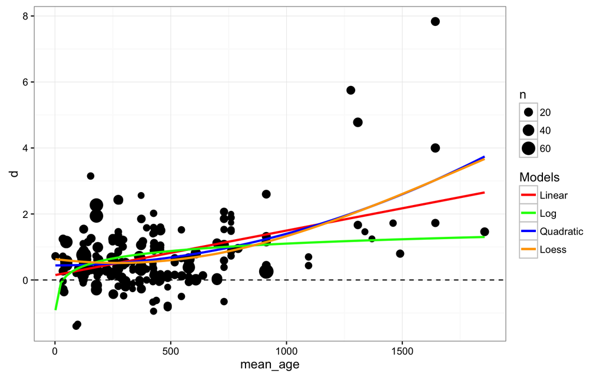

Next, we examine the curves for each plot data set sepatately.

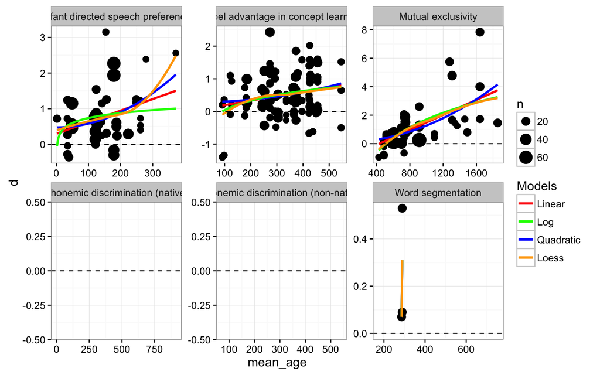

# 3 Simple Regressions

To see if one particular type of model is a better fit of the data, we run each model and the compare them with an ANOVA.

```r
lin_mod <- lm(d ~ mean_age, weights = 1/d_var, data = all_data)
log_mod <- lm(d ~ log(mean_age), weights = 1/d_var, data = all_data)
quad_mod <- lm(d ~ I(mean_age^2), weights = 1/d_var, data = all_data)
```

Examine each model and look at head to head comparisions.

```r
summary(lin_mod)
```

```
##
## Call:
## lm(formula = d ~ mean_age, data = all_data, weights = 1/d_var)
##
## Weighted Residuals:
##     Min      1Q  Median      3Q     Max
## -4.0105 -1.3028 -0.0697  1.4236  7.6781
##
## Coefficients:
##              Estimate Std. Error t value Pr(>|t|)
## (Intercept) 0.3686797  0.0790005   4.667 5.48e-06 ***
## mean_age    0.0005802  0.0001615   3.592 0.000409 ***
## ---
## Signif. codes:  0 '***' 0.001 '**' 0.01 '*' 0.05 '.' 0.1 ' ' 1
##
## Residual standard error: 2.086 on 208 degrees of freedom
##   (442 observations deleted due to missingness)
## Multiple R-squared:  0.05841,    Adjusted R-squared:  0.05389
## F-statistic:  12.9 on 1 and 208 DF,  p-value: 0.0004093
```

```r
summary(log_mod)
```

```
##
## Call:
## lm(formula = d ~ log(mean_age), data = all_data, weights = 1/d_var)
##
## Weighted Residuals:
##     Min      1Q  Median      3Q     Max
## -4.1264 -1.3145 -0.0243  1.5055  7.6042
##
## Coefficients:
##               Estimate Std. Error t value Pr(>|t|)
## (Intercept)    0.08194    0.31680   0.259    0.796
## log(mean_age)  0.09061    0.05555   1.631    0.104
##
## Residual standard error: 2.136 on 208 degrees of freedom
##   (442 observations deleted due to missingness)
## Multiple R-squared:  0.01263,    Adjusted R-squared:  0.007884
## F-statistic: 2.661 on 1 and 208 DF,  p-value: 0.1044
```

```r
summary(quad_mod)
```

```
##
## Call:
## lm(formula = d ~ I(mean_age^2), data = all_data, weights = 1/d_var)
##
## Weighted Residuals:
##     Min      1Q  Median      3Q     Max
## -4.0783 -1.2548 -0.0472  1.4776  7.6396
##
## Coefficients:
##                Estimate Std. Error t value Pr(>|t|)
## (Intercept)   4.644e-01  5.465e-02   8.499 3.70e-15 ***
## I(mean_age^2) 5.344e-07  1.122e-07   4.763 3.57e-06 ***
## ---
## Signif. codes:  0 '***' 0.001 '**' 0.01 '*' 0.05 '.' 0.1 ' ' 1
##
## Residual standard error: 2.041 on 208 degrees of freedom
##   (442 observations deleted due to missingness)
## Multiple R-squared:  0.09835,    Adjusted R-squared:  0.09401
## F-statistic: 22.69 on 1 and 208 DF,  p-value: 3.571e-06
```

```r
anova(lin_mod, log_mod)
```

```
## Analysis of Variance Table
##
## Model 1: d ~ mean_age
## Model 2: d ~ log(mean_age)
##   Res.Df    RSS Df Sum of Sq F Pr(>F)
## 1    208 905.26
## 2    208 949.28  0   -44.016
```

```r
anova(lin_mod, quad_mod)
```

```
## Analysis of Variance Table
##
## Model 1: d ~ mean_age
## Model 2: d ~ I(mean_age^2)
##   Res.Df    RSS Df Sum of Sq F Pr(>F)
## 1    208 905.26
## 2    208 866.87  0    38.394
```

```r
anova(log_mod, quad_mod)
```

```
## Analysis of Variance Table
##
## Model 1: d ~ log(mean_age)
## Model 2: d ~ I(mean_age^2)
##   Res.Df    RSS Df Sum of Sq F Pr(>F)
## 1    208 949.28
## 2    208 866.87  0     82.41
```

We also built and compared models with single predictors to those with multiple predictors.

```r
lin_log_mod <- lm(d ~ mean_age + log(mean_age),
                  weights = 1/d_var,
                  data = all_data)
summary(lin_log_mod)
```

```
##
## Call:
## lm(formula = d ~ mean_age + log(mean_age), data = all_data, weights = 1/d_var)
##
## Weighted Residuals:
##     Min      1Q  Median      3Q     Max
## -4.1844 -1.2608 -0.0892  1.4708  7.7555
##
## Coefficients:
##                 Estimate Std. Error t value Pr(>|t|)
## (Intercept)    1.5424652  0.4691865   3.288  0.00119 **
## mean_age       0.0012106  0.0002952   4.101 5.92e-05 ***
## log(mean_age) -0.2515187  0.0991387  -2.537  0.01192 *
## ---
## Signif. codes:  0 '***' 0.001 '**' 0.01 '*' 0.05 '.' 0.1 ' ' 1
##
## Residual standard error: 2.059 on 207 degrees of freedom
##   (442 observations deleted due to missingness)
## Multiple R-squared:  0.08681,    Adjusted R-squared:  0.07799
## F-statistic: 9.839 on 2 and 207 DF,  p-value: 8.282e-05
```

```r
anova(lin_mod, lin_log_mod)
```

```
## Analysis of Variance Table
##
## Model 1: d ~ mean_age
## Model 2: d ~ mean_age + log(mean_age)
##   Res.Df    RSS Df Sum of Sq      F  Pr(>F)
## 1    208 905.26
## 2    207 877.96  1      27.3 6.4366 0.01192 *
## ---
## Signif. codes:  0 '***' 0.001 '**' 0.01 '*' 0.05 '.' 0.1 ' ' 1
```

```r
anova(log_mod, lin_log_mod)
```

```
## Analysis of Variance Table
##
## Model 1: d ~ log(mean_age)
## Model 2: d ~ mean_age + log(mean_age)
##   Res.Df    RSS Df Sum of Sq      F    Pr(>F)
## 1    208 949.28
## 2    207 877.96  1    71.316 16.814 5.921e-05 ***
## ---
## Signif. codes:  0 '***' 0.001 '**' 0.01 '*' 0.05 '.' 0.1 ' ' 1
```

Let’s look at what that graph looks like on a plot.

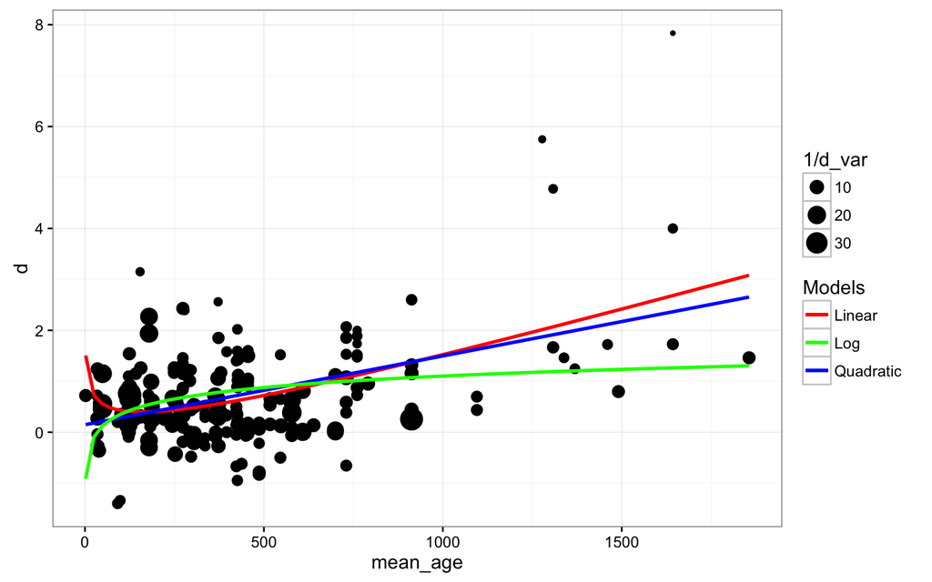

This tells us that modeling the whole dataset doesn’t make sense.

# 4 Mixed-effects regression

[A very informative post on the difference between `rma` and `lm`/`lmer`](http://www.metafor-project.org/doku.php/tips:rma_vs_lm_and_lme) suggests that we want to do random effects MA in `lme` by setting `control=lmeControl(sigma = 1)`. But we can’t do that under `lme4`. There’s [a branch of lme4](https://github.com/lme4/lme4/issues/224) that deals with this, but it looks pretty intense.

So we’ll eat this issue for now but note that we may want to go back and do this using metafor.

## 4.1 Simple mixed-effects

As a second step ran mixed effects regressions where data set was included as a random intercept.

```r
lin_lmer <- lmer(d ~ mean_age +
                   (1 | dataset),
                 weights = 1/d_var,
                 data = all_data)
coef(summary(lin_lmer))
```

```
##                Estimate   Std. Error    t value
## (Intercept) -0.04325974 0.3176045629 -0.1362063
## mean_age     0.00159464 0.0002603371  6.1252908
```

```r
log_lmer <- lmer(d ~ log(mean_age) +
                   (1 | dataset),
                 weights = 1/d_var,
                 data = all_data)
coef(summary(log_lmer))
```

```
##                 Estimate Std. Error   t value
## (Intercept)   -0.8954803 0.52186716 -1.715916
## log(mean_age)  0.2652477 0.08707416  3.046227
```

```r
quad_lmer <- lmer(d ~ I(mean_age^2) +
                   (1 | dataset),
                 weights = 1/d_var,
                 data = all_data)
coef(summary(quad_lmer))
```

```
##                   Estimate   Std. Error  t value
## (Intercept)   3.990636e-01 1.539839e-01 2.591594
## I(mean_age^2) 7.709169e-07 1.366078e-07 5.643286
```

and the joint, log+linear model

```r
log_lin_lmer <- lmer(d ~ mean_age + log(mean_age) +
                   (1| dataset),
                 weights = 1/d_var,
                 data = all_data)
coef(summary(log_lin_lmer))
```

```
##                   Estimate   Std. Error    t value
## (Intercept)    0.261688204 0.6278359073  0.4168099
## mean_age       0.001704306 0.0003363545  5.0669930
## log(mean_age) -0.061738933 0.1121705940 -0.5504021
```

ANOVA - hard to interpret?

```r
anova(lin_lmer, log_lmer)
```

```
## Data: all_data
## Models:
## lin_lmer: d ~ mean_age + (1 | dataset)
## log_lmer: d ~ log(mean_age) + (1 | dataset)
##          Df    AIC    BIC  logLik deviance Chisq Chi Df Pr(>Chisq)
## lin_lmer  4 470.89 484.27 -231.44   462.89
## log_lmer  4 492.84 506.23 -242.42   484.84     0      0          1
```

```r
anova(lin_lmer, log_lin_lmer)
```

```
## Data: all_data
## Models:
## lin_lmer: d ~ mean_age + (1 | dataset)
## log_lin_lmer: d ~ mean_age + log(mean_age) + (1 | dataset)
##              Df    AIC    BIC  logLik deviance  Chisq Chi Df Pr(>Chisq)
## lin_lmer      4 470.89 484.27 -231.44   462.89
## log_lin_lmer  5 472.47 489.21 -231.24   462.47 0.4142      1     0.5199
```

Let’s look at these.

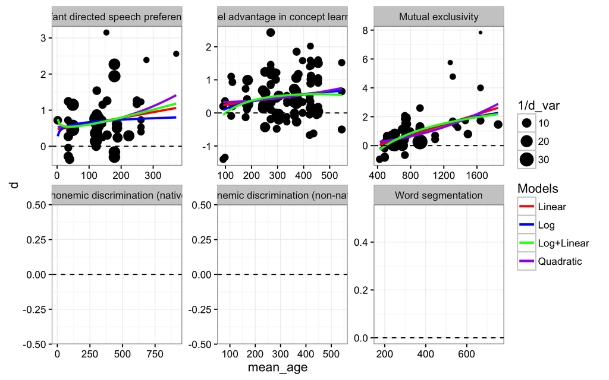

Now try to plot actual model.

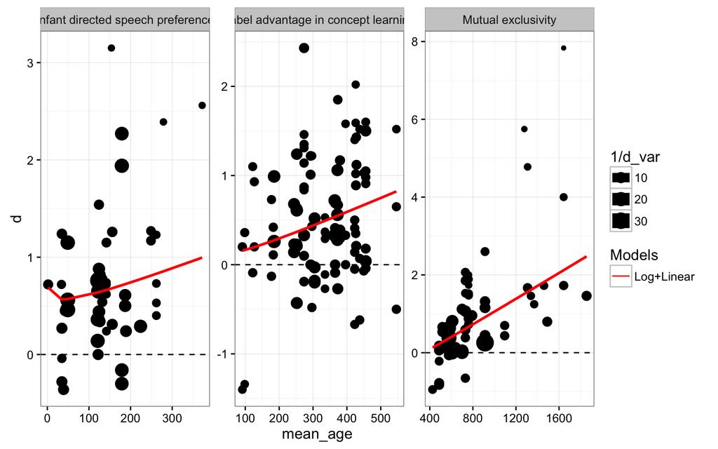

Summary - this looks pretty good, seems like the linear model is somehow smoothing the logs at the edges, and the random effects are working to capture cross-dataset variability.

## 4.2 Mixed effects with nested paper effects

Next add nested paper effects?

```r
log_lin_paper_lmer <- lmer(d ~ mean_age + log(mean_age) +
                             (1 | dataset / unique_ID),
                           weights = 1/d_var,
                           data = all_data)
coef(summary(log_lin_paper_lmer))
```

```
##                  Estimate   Std. Error    t value
## (Intercept)    0.14052005 0.7024667468  0.2000380
## mean_age       0.00161832 0.0003516846  4.6016225
## log(mean_age) -0.03339743 0.1270858571 -0.2627942
```

```r
#anova(log_lin_paper_lmer, log_lin_paper_int_lmer)
```

We now predict from this model, attempting to remove the nested paper effect (set to zero for generalization). Blue is the new model.

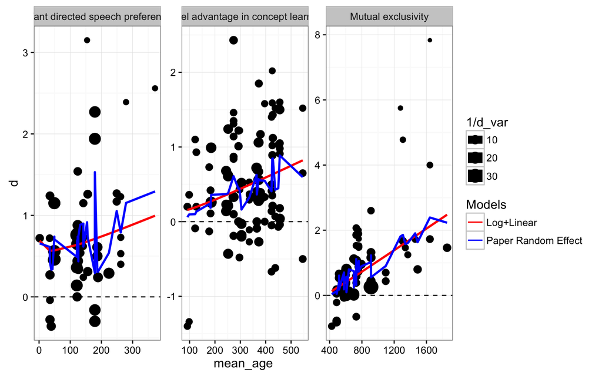

## 4.3 Subset to only those papers with multiple ages

Let’s check whether we can feel better about the overfitting issue by subsetting to papers with more than one age, so we are getting better confidence on the random slope.

### 4.3.1 Two age groups.

```r
multiage_data <- all_data_preds %>%
  group_by(dataset, unique_ID) %>%
  mutate(count_ages = length(unique(floor(mean_age/2)))) %>%
  filter(count_ages > 1)

nested_multiage_lmer <- lmer(d ~ mean_age + log(mean_age) +
                             (log(mean_age) | dataset / unique_ID),
                           weights = 1/d_var,
                           data = multiage_data)
coef(summary(nested_multiage_lmer))
```

```
##                   Estimate   Std. Error    t value
## (Intercept)   -3.014040353 3.3047546154 -0.9120315
## mean_age       0.001127685 0.0005028636  2.2425269
## log(mean_age)  0.481778921 0.4955913332  0.9721294
```

Wow - much better.

Plot this. Again, blue is new.

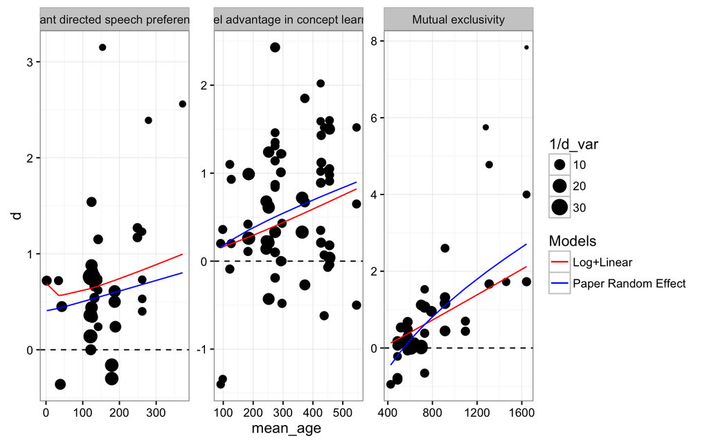

### 4.3.2 Three age groups

```
##                   Estimate   Std. Error    t value
## (Intercept)    1.096448367 1.7365910109  0.6313797
## mean_age       0.003174894 0.0007600731  4.1770906
## log(mean_age) -0.311245149 0.3468974788 -0.8972252
```

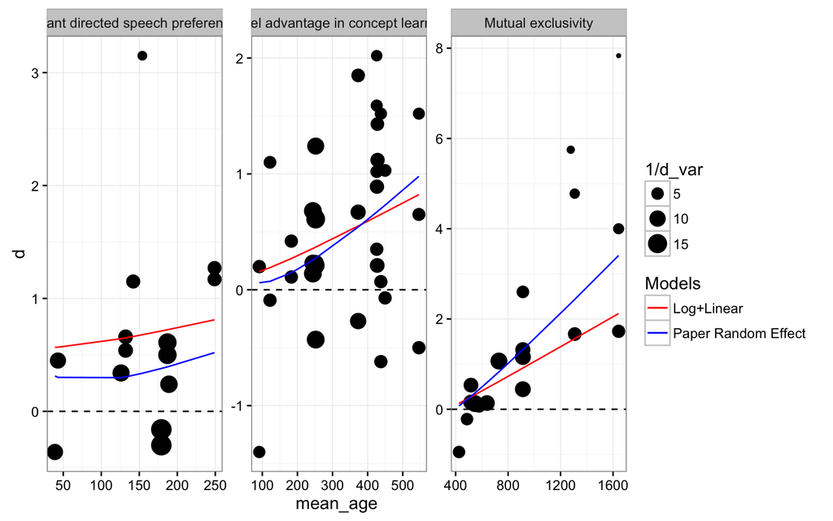

### 4.3.3 Two age groups, no slope per paper

```
##                   Estimate   Std. Error    t value
## (Intercept)   -2.795718340 3.1805249725 -0.8790116
## mean_age       0.001293318 0.0004153072  3.1141250
## log(mean_age)  0.433142550 0.4687717474  0.9239946
```

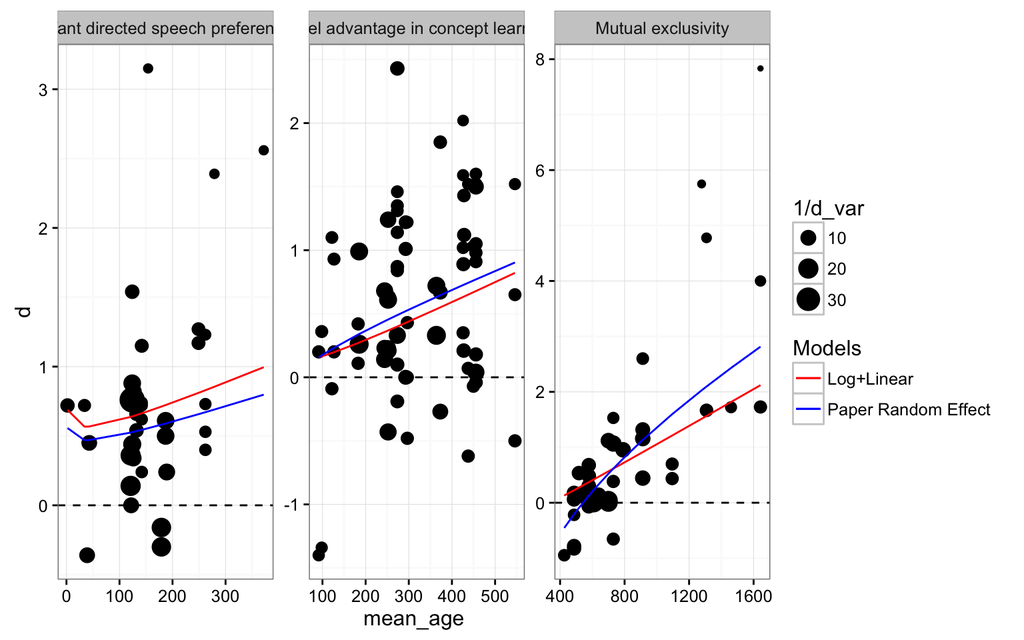

Conclusion: Paper-level random effects make a really big difference here. Hard to know what to make of this.

# 5 Conclusions